# Presentation

Group 313:2

10/12/2019

## Introduction

YouTube uses a combination of factors including measuring user interactions (number of views, shares, comments, and likes). Our goal is mainly to use these metrics to see if there are patterns in what videos trend in different countries, and see how these different metrics vary over trending videos.

## Background

We found our data set on Kaggle.

We have data for 8 countries ( USA, Great Britain, Canada, France, Russia, Mexico, Japan, and India) about top trending videos over 205 days in CSV and we have categories id referenced in JSON. There are 16 columns:

- video_id: contains a unique id of the video (string)
- trending_date: the date when this video was trending. (date)
- title: title of that video (string)
- channel_title: the channel name from where it was published (string)
- category_id: id of category reference from JSON (number)
- publish_time: time video was published (date)
- tags: tags for the video (string)
- views: # of views on that video (number)
- likes: # of likes on that video (number)
- dislikes: # of dislikes on that video (number)
- comment_count: #of comments on that video (number)
- thumbnail_link: thumbnail link of that video (string)
- comments_disabled: are comments disabled on that video (bool)
- ratings_disabled: are ratings disabled on that video (bool)
- video_error_or_removed: is videos removed or there is an error (bool)
- description: description of that videos (string)

## Analysis

### 1

> Which categories have the most likes?
- Filter the data set to only include category, view, likes, dislikes, and comments (if any). -Determine which categories have the most likes by summing up the number of likes between each category and arranging them by number of likes

```
## # A tibble: 5 x 2
##   category_title       likes
##   <chr>                <dbl>
## 1 Music            564447530
## 2 Entertainment    387245433
## 3 Comedy           196046674
## 4 People & Blogs   105388564
## 5 Film & Animation  77802003
```

```
## # A tibble: 5 x 2
##   category_title        likes
##   <chr>                 <dbl>
## 1 Music            1416838584
## 2 Entertainment     530516491
## 3 Comedy            216346746
## 4 People & Blogs    186615999
## 5 Film & Animation  165997476
```

```
## # A tibble: 5 x 2
##   category_title     likes
##   <chr>              <dbl>
## 1 Music          277314234
## 2 Comedy         130805444
## 3 Entertainment  118243560
## 4 Sports          43964560
## 5 People & Blogs  28927705
```

```
## # A tibble: 5 x 2
##   category_title     likes
##   <chr>              <dbl>
## 1 Music          227013300
## 2 Entertainment  186692595
## 3 Comedy          55273506
## 4 People & Blogs  47859054
## 5 Sports          30866251
```

```
## # A tibble: 5 x 2
##   category_title        likes
##   <chr>                 <dbl>
## 1 Music            3742993052
## 2 Entertainment     744266231
## 3 Film & Animation  147418633
## 4 Comedy            143372176
## 5 People & Blogs    135396249
```

```
## # A tibble: 5 x 2
##   category_title       likes
##   <chr>                <dbl>
## 1 Entertainment    396146637
## 2 Music            254328536
## 3 Comedy           174114686
## 4 Film & Animation  69241553
## 5 Sports            32969986
```

```
## # A tibble: 5 x 2
##   category_title      likes
##   <chr>               <dbl>
## 1 Music            83596720
## 2 Entertainment    39741269
## 3 People & Blogs    9696311
## 4 Comedy            7547588
## 5 Film & Animation  5920614
```

```
## # A tibble: 5 x 2
##   category_title           likes
##   <chr>                    <dbl>
## 1 Music                120129951
## 2 Entertainment         98904908
## 3 People & Blogs        73222107
## 4 Comedy                69987601
## 5 Science & Technology  25866814
```

```
## [1] "All Countries Combined"
```

```
## # A tibble: 5 x 2
##   category_title        likes
##   <chr>                 <dbl>
## 1 Music            6686661907
## 2 Entertainment    2501757124
## 3 Comedy            993494421
## 4 People & Blogs    610300718
## 5 Film & Animation  528077118
```

### 2

> Which categories have the most comments?

-Repeat number 1 with comments

```
## # A tibble: 5 x 2
##   category_title   comment_count
##   <chr>                    <dbl>
## 1 Entertainment         55313036
## 2 Music                 52435252
## 3 Comedy                19638776
## 4 People & Blogs        16818201
## 5 Film & Animation      10086573
```

```
## # A tibble: 5 x 2
##   category_title comment_count
##   <chr>                  <dbl>
## 1 Music              125296396
## 2 Entertainment       73566498
## 3 People & Blogs      24778032
## 4 Howto & Style       23149550
## 5 Comedy              22545582
```

```
## # A tibble: 5 x 2
##   category_title comment_count
##   <chr>                  <dbl>
## 1 Music               25446289
## 2 Entertainment       15729924
## 3 Comedy               9136814
## 4 Sports               4575418
## 5 People & Blogs       4104818
```

```
## # A tibble: 5 x 2
##   category_title comment_count
##   <chr>                  <dbl>
## 1 Entertainment       29688886
## 2 Music               21744565
## 3 People & Blogs       7304854
## 4 Comedy               6838587
## 5 Howto & Style        3682138
```

```
## # A tibble: 5 x 2
##   category_title   comment_count
##   <chr>                    <dbl>
## 1 Music                293013140
## 2 Entertainment        116897440
## 3 People & Blogs        18713149
## 4 Comedy                16718816
## 5 Film & Animation      15590011
```

```
## # A tibble: 5 x 2
##   category_title       comment_count
##   <chr>                        <dbl>
## 1 Entertainment             42199473
## 2 Music                     17595070
## 3 Comedy                    13806968
## 4 Science & Technology       9664392
## 5 Film & Animation           5789446
```

```
## # A tibble: 5 x 2
##   category_title comment_count
##   <chr>                  <dbl>
## 1 Music               11129839
## 2 Entertainment        6052118
## 3 People & Blogs       1669164
## 4 Comedy               1229425
## 5 Sports               1051743
```

```
## # A tibble: 5 x 2
##   category_title       comment_count
##   <chr>                        <dbl>
## 1 Entertainment             14324340
## 2 Music                     13197717
## 3 People & Blogs            11694645
## 4 Comedy                     8269629
## 5 Science & Technology       5700658
```

```
## [1] "All Countries Combined"
```

```
## # A tibble: 5 x 2
##   category_title   comment_count
##   <chr>                    <dbl>
## 1 Music                559858268
## 2 Entertainment        353771715
## 3 Comedy                98184597
## 4 People & Blogs        87744783
## 5 Film & Animation      57262381
```

Similar the the earlier question, Music and Entertainment have a consistent presence in the top 3 categories. People & Blogs is also a common category in the top 3. This is most likely due to the more interactive relationship between the youtubers and their audience in this category.

##3

> Are there any trending videos with more dislikes than likes? If so, how many? What categories are most common in this case?

```
## # A tibble: 5 x 2
##   category_title       n
##   <chr>            <int>
## 1 News & Politics     78
## 2 People & Blogs      61
## 3 Entertainment       58
## 4 Sports              27
## 5 Film & Animation    10
```

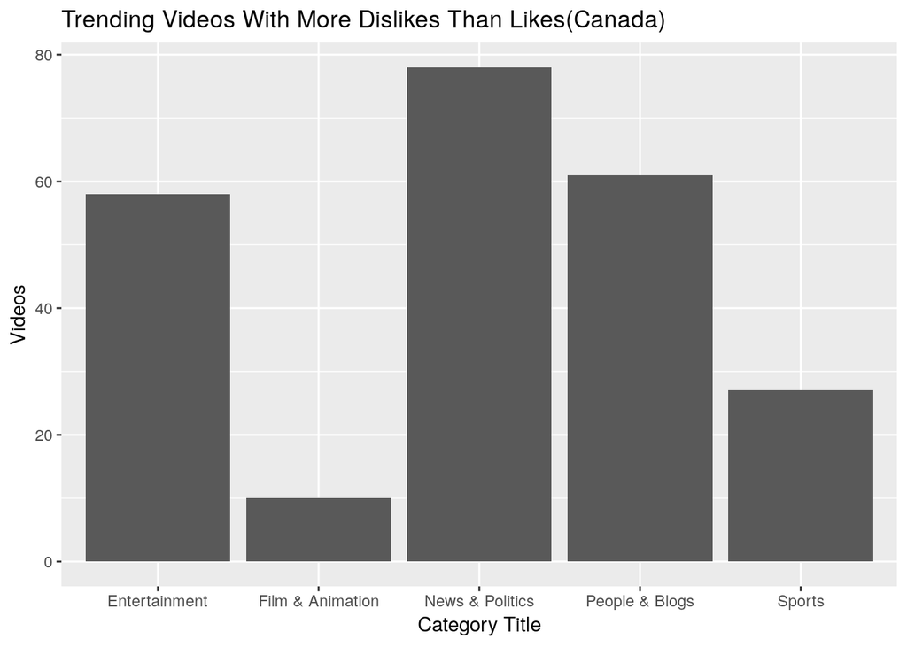

```
## # A tibble: 5 x 2
##   category_title       n
##   <chr>            <int>
## 1 News & Politics    245
## 2 Entertainment      156
## 3 Sports              52
## 4 People & Blogs      32
## 5 Film & Animation    26
```

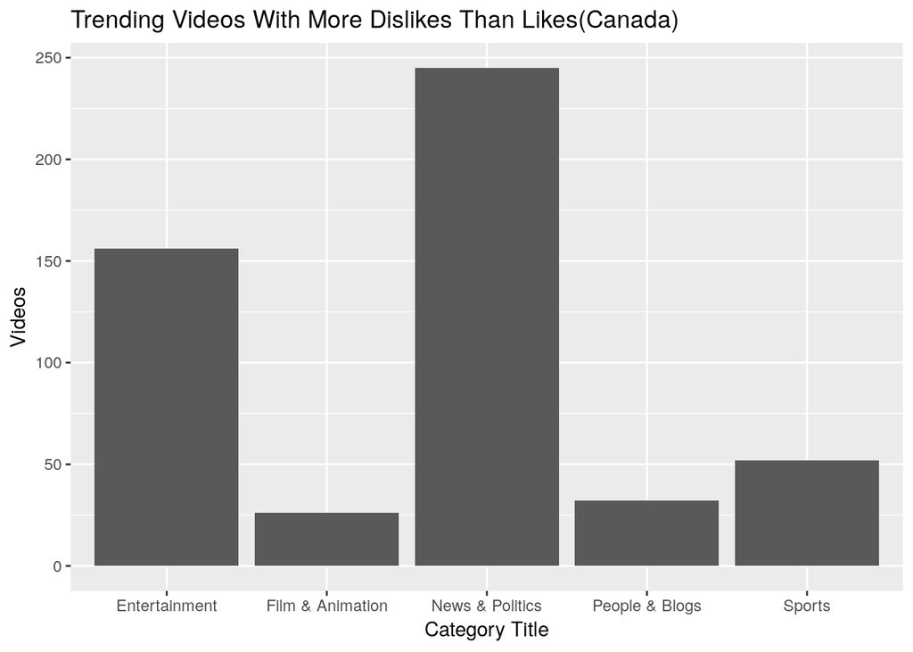

```
## # A tibble: 5 x 2
##   category_title      n
##   <chr>           <int>
## 1 News & Politics   157
## 2 People & Blogs    154
## 3 Entertainment      95
## 4 Sports             18
## 5 Gaming             16
```

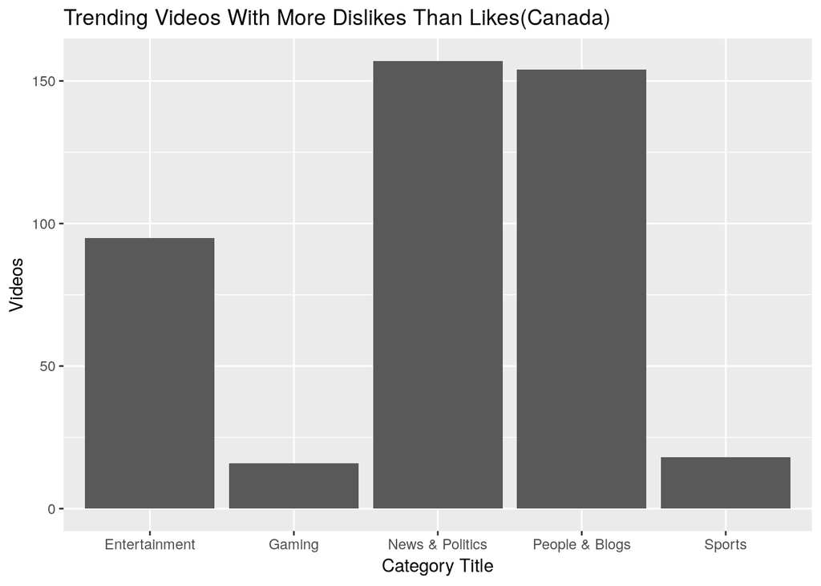

```
## # A tibble: 5 x 2
##   category_title      n
##   <chr>           <int>
## 1 Entertainment     182
## 2 People & Blogs    138
## 3 News & Politics    78
## 4 Sports             51
## 5 Music              14
```

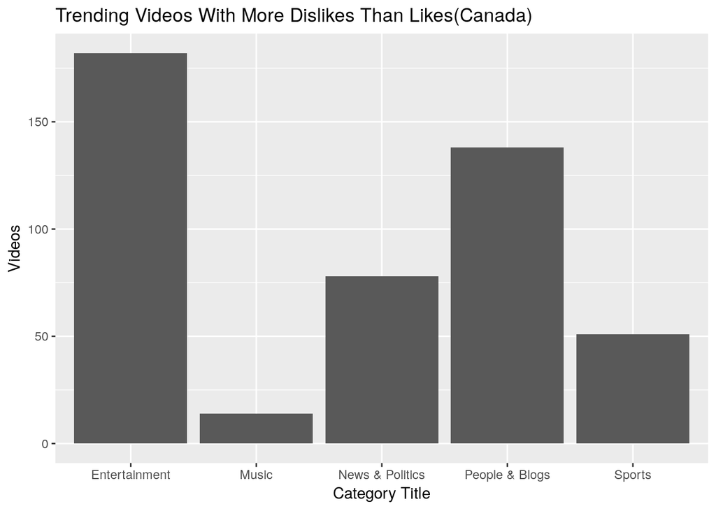

```
## # A tibble: 5 x 2
##   category_title       n
##   <chr>            <int>
## 1 Entertainment      127
## 2 People & Blogs     105
## 3 Sports              91
## 4 News & Politics     85
## 5 Film & Animation    23
```

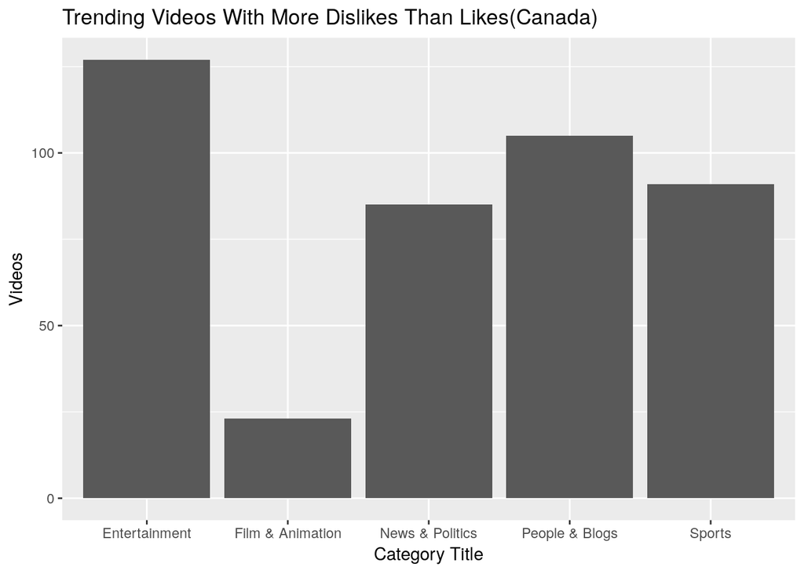

```
## # A tibble: 5 x 2
##   category_title       n
##   <chr>            <int>
## 1 Entertainment      413
## 2 News & Politics    163
## 3 People & Blogs      52
## 4 Film & Animation     6
## 5 Shows                4
```

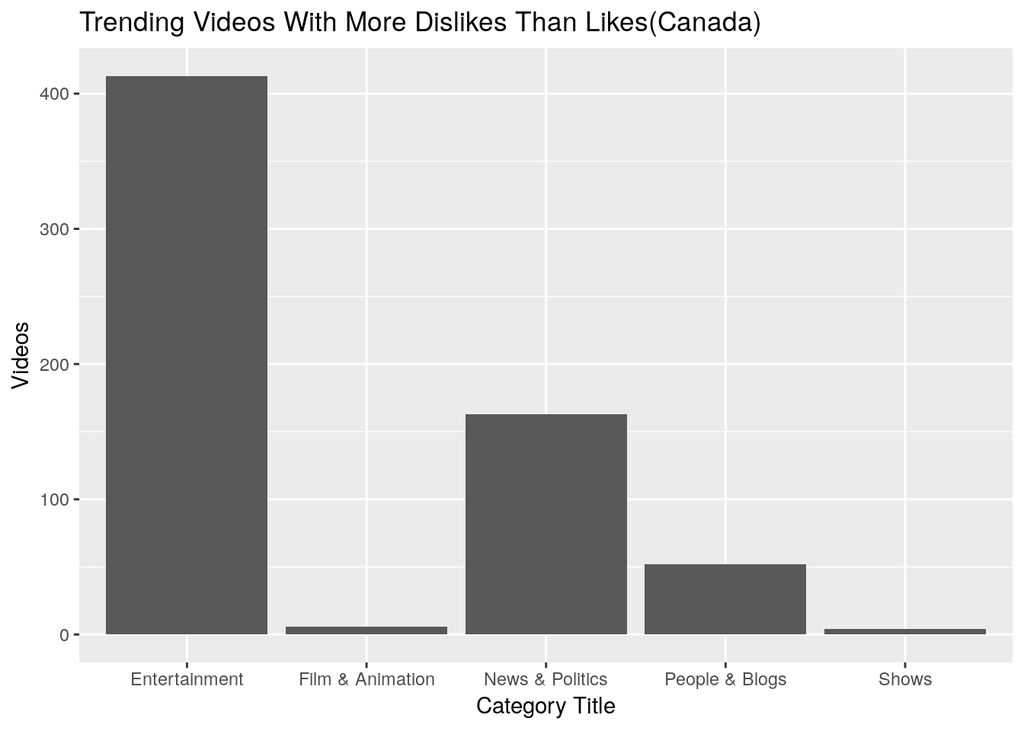

```
## # A tibble: 5 x 2
##   category_title       n
##   <chr>            <int>
## 1 Entertainment      254
## 2 People & Blogs     222
## 3 News & Politics    122
## 4 Sports              67
## 5 Film & Animation    33
```

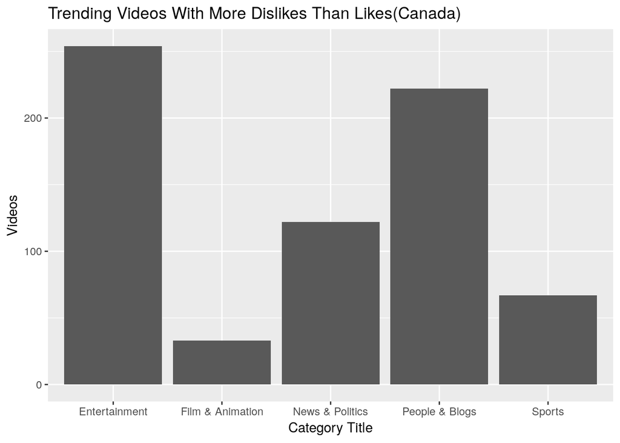

```
## # A tibble: 5 x 2
##   category_title       n
##   <chr>            <int>
## 1 News & Politics    738
## 2 People & Blogs     583
## 3 Entertainment      199
## 4 Comedy             105
## 5 Film & Animation    71
```

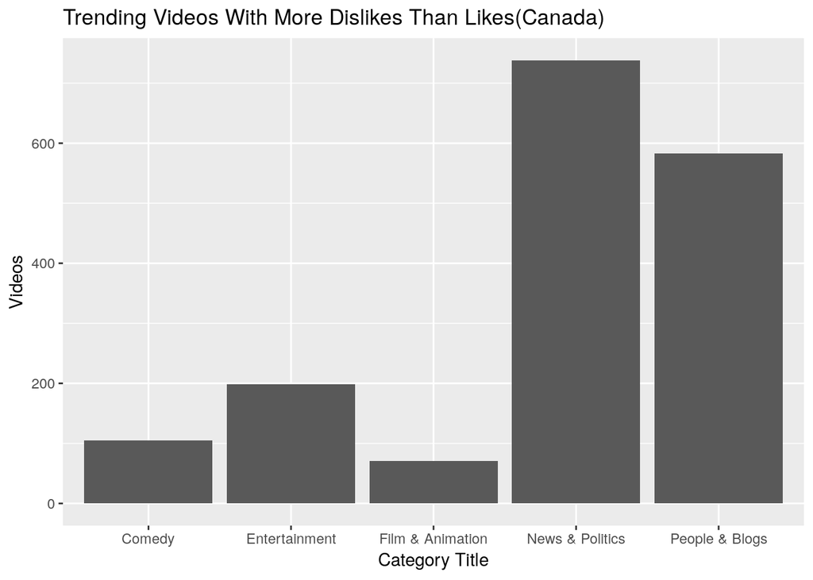

### Clickbait

We generally defined clickbait as any video with a title meeting any of the following criteria: it contains no lowercase letters, it contains 8 or more characters in a row that are either whitespace, an exclamation point, or a capital letter, or it contains a “?!” or “!?”. There are a few exceptions to these rules, but those are not too common.

### 4

> How prevalent is clickbait? How do the average number of views vary?

```
## # A tibble: 10 x 6
##    country       clickbait     n  total_views average_views percent
##    <chr>         <lgl>     <int>        <dbl>         <dbl>   <dbl>
##  1 USA           FALSE     32596  80939889704      2483123.   0.807
##  2 USA           TRUE       7775  14791744748      1902475.   0.193
##  3 France        FALSE     21567  11795896753       546942.   0.572
##  4 France        TRUE      16134   4797605493       297360.   0.428
##  5 Great Britain FALSE     30575 204103753458      6675511.   0.799
##  6 Great Britain TRUE       7684  24310529276      3163786.   0.201
##  7 Mexico        FALSE     21622   9342825437       432098.   0.599
##  8 Mexico        TRUE      14463   3963879831       274070.   0.401
##  9 Canada        FALSE     28660  36068708375      1258503.   0.725
## 10 Canada        TRUE      10855  10101277527       930564.   0.275
```

Clickbait seems to be the more prevalent in France and Mexico (about 40% of trending videos are clickbait) and less prevalent in the US and Great Britain (about 20% of trending videos are clickbait).

### 5

> How well do people receive clickbait?

#### Hypothesis Tests for difference in likes and dislikes per view (separate)

$$H_0: p_C = p_N \\
H_A: p_C \neq p_N$$

```
## [1] "Likes:"
```

```
## # A tibble: 5 x 4
##   cb_LV_greater z_score  p_value country
##   <lgl>           <dbl>    <dbl> <chr>
## 1 TRUE             6.13 4.48e-10 USA
## 2 TRUE             9.39 0.       France
## 3 TRUE             8.71 0.       Great Britain
## 4 TRUE            10.2  0.       Mexico
## 5 TRUE             5.49 1.99e- 8 Canada
```

```
## [1] "Dislikes:"
```

```
## # A tibble: 5 x 4
##   cb_DV_greater z_score p_value country
##   <lgl>           <dbl>   <dbl> <chr>
## 1 FALSE          0.0619   0.475 USA
## 2 TRUE           0.119    0.452 France
## 3 TRUE           0.235    0.407 Great Britain
## 4 TRUE           0.125    0.450 Mexico
## 5 FALSE          0.140    0.444 Canada
```

For the tests for a difference in the proportion of likes/view in clickbait vs. non-clickbait videos in these 5 countries, our p-values are approximately 0, which are highly statistically significant. We therefore have very convincing evidence that the proportion of likes/view is higher for clickbait videos than for non-clickbait videos in those 5 countries.

For the tests for a difference in the proportion of dislikes/view in clickbait vs. non-clickbait videos in these 5 countries, our p-values are 0.475, 0.452, 0.407, and 0.450, non of which is statistically significant. We therefore do not have convincing evidence of a difference in the proportion of dislikes/view for clickbait videos vs. non-clickbait videos in any of those 5 countries.

### 6

> Which categories are clickbait the most frequently in each country?

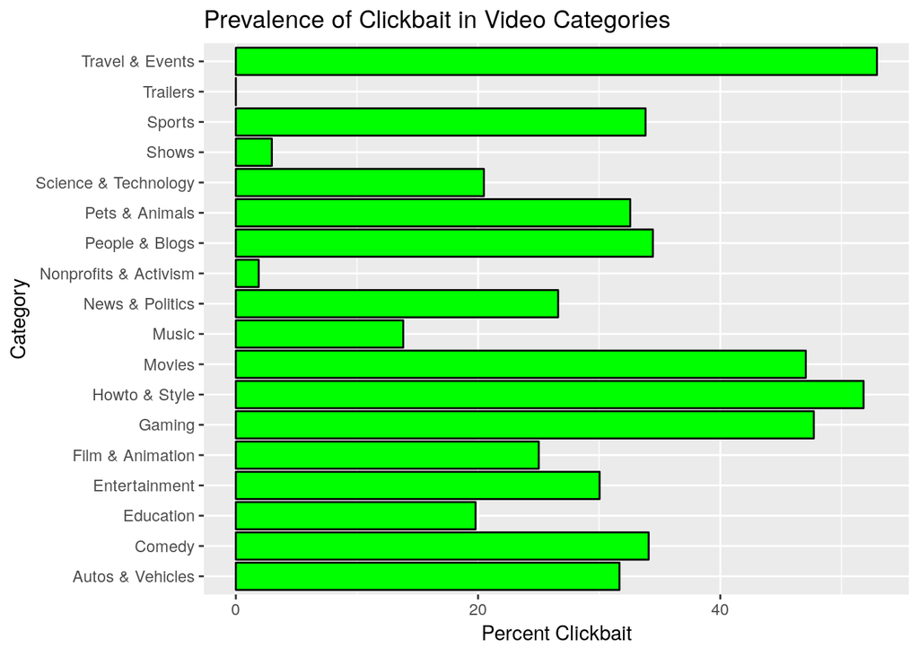

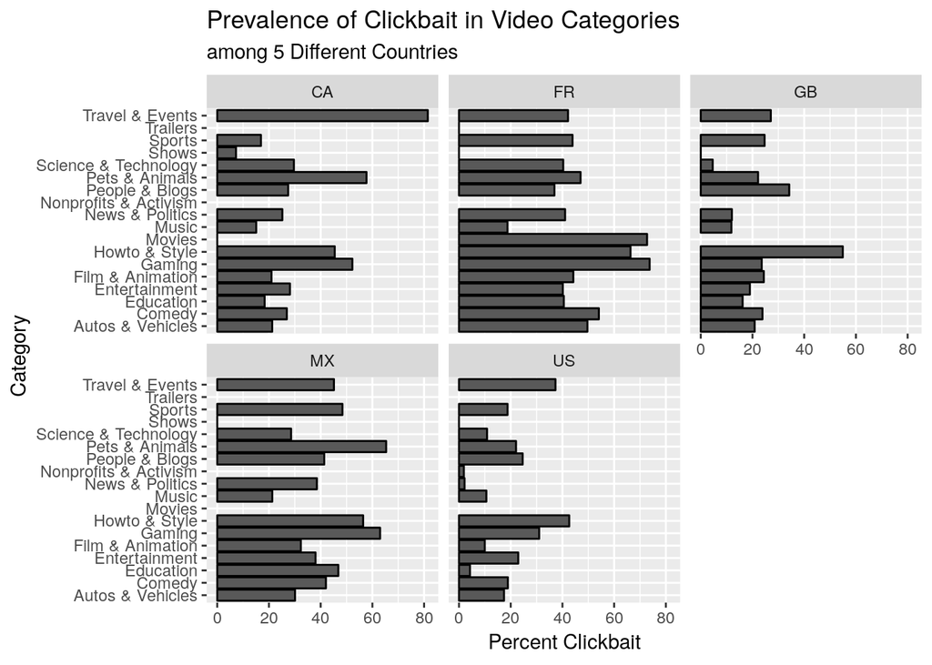

Movies, how-to & style, gaming, and travel & events tend to be clickbait the most frequently. A typical frequency of clickbait for a video category would be around 20-40%, with categories trailers, nonprofits/activism, and shows having clickbait the least frequently (less than 3% of videos in those categories are clickbait.)

In most video categories, France and Mexico have clickbait videos more frequently. The margin for this differs across categories, and it varies across categories whether France or Mexico has a higher clickbait frequency. In some categories, Canada has a higher frequency of clickbait as well.

### 8

## do the same channels trend in each country? ( find top 10 trending channels separately for each country )

- Filter the data set to include only channel titles and views.
- Determine the top 10 channels that trend in each country by summing up the views and arranging them by number of views.

```
## # A tibble: 10 x 2
##    channel_title                    views
##    <chr>                            <dbl>
##  1 Marvel Entertainment        1011420205
##  2 T-Series                     799114025
##  3 Dude Perfect                 729916338
##  4 YouTube Spotlight            635976769
##  5 ibighit                      511567918
##  6 PewDiePie                    461700524
##  7 Sony Pictures Entertainment  451188760
##  8 Speed Records                426604974
##  9 20th Century Fox             419577035
## 10 ChildishGambinoVEVO          411775069
```

```
## # A tibble: 10 x 2
##    channel_title            views
##    <chr>                    <dbl>
##  1 Dude Perfect         305226697
##  2 ibighit              291768132
##  3 YouTube Spotlight    254422431
##  4 PewDiePie            243522111
##  5 Marvel Entertainment 223358474
##  6 TaylorSwiftVEVO      174371361
##  7 MLG Highlights       163697067
##  8 Çukur                163668822
##  9 ChildishGambinoVEVO  153765066
## 10 Ed Sheeran           147303194
```

```
## # A tibble: 10 x 2
##    channel_title             views
##    <chr>                     <dbl>
##  1 NickyJamTV           8516190092
##  2 Ozuna                8305198063
##  3 Bad Bunny            6891280759
##  4 DrakeVEVO            6581834413
##  5 ChildishGambinoVEVO  6101309613
##  6 Flow La Movie        5151438858
##  7 ArianaGrandeVevo     4107436350
##  8 Marvel Entertainment 3993421220
##  9 jypentertainment     3624070589
## 10 Ed Sheeran           3589056783
```

```
## # A tibble: 10 x 2
##    channel_title                    views
##    <chr>                            <dbl>
##  1 T-Series                    2124607907
##  2 Marvel Entertainment        1280396202
##  3 FoxStarHindi                1260807619
##  4 Amit Bhadana                1024252169
##  5 Speed Records                801739414
##  6 Sony Pictures Entertainment  772261898
##  7 Zee Music Company            694640267
##  8 Goldmines Telefilms          643826504
##  9 Dude Perfect                 598578613
## 10 YRF                          573884674
```

```
## # A tibble: 10 x 2
##    channel_title                   views
##    <chr>                           <dbl>
##  1 ibighit                     338728753
##  2 Marvel Entertainment        153285154
##  3 MLG Highlights              106078533
##  4 Sony Pictures Entertainment  90070123
##  5 SpaceX                       84901008
##  6 TaylorSwiftVEVO              78166154
##  7 東海オンエア                 74293753
##  8 水溜りボンド                 70939666
##  9 Sơn Tùng M-TP Official       68327404
## 10 Fischer's-フィッシャーズ-    63393802
```

```
## # A tibble: 10 x 2
##    channel_title            views
##    <chr>                    <dbl>
##  1 Marvel Entertainment 383058026
##  2 YouTube Spotlight    255273304
##  3 ibighit              251466087
##  4 MalumaVEVO           226697506
##  5 Dude Perfect         172934487
##  6 NickyJamTV           162371871
##  7 DrossRotzank         160722189
##  8 PewDiePie            154828754
##  9 Ozuna                144610384
## 10 Cracks               143870186
```

```
## # A tibble: 10 x 2
##    channel_title             views
##    <chr>                     <dbl>
##  1 ibighit               238699889
##  2 Трум Трум             178367393
##  3 PewDiePie             145729987
##  4 вДудь                 127282959
##  5 Алексей Навальный     125499738
##  6 SlivkiShow            123175267
##  7 Wylsacom              112156010
##  8 SOBOLEV               101953840
##  9 Мастерская Настроения  90552175
## 10 AcademeG               88411224
```

```
## # A tibble: 10 x 2
##    channel_title                    views
##    <chr>                            <dbl>
##  1 ChildishGambinoVEVO         3758488765
##  2 ibighit                     2235906679
##  3 Dude Perfect                1870085178
##  4 Marvel Entertainment        1808998971
##  5 ArianaGrandeVevo            1576959172
##  6 MalumaVEVO                  1551515831
##  7 jypentertainment            1486972132
##  8 Sony Pictures Entertainment 1432374398
##  9 FoxStarHindi                1238609854
## 10 BeckyGVEVO                  1182971286
```

There are no channels that trend in the top 10 of every country. There are a couple channels that trend in more than one country. Marvel Entertainment trends in 7 of the countries, making it the most popular amongst all 8 countries. The next most popular channel is ibighit, trending in 6 countries. Dude Perfect trends in 5, and PewDiePie, Sony Pictures Entertainment, and ChildishGambinoVEVO all trend in 4.

[output not shown]

```
## # A tibble: 80 x 5
##    Channel_Title                    Views country channel_title views
##    <chr>                            <dbl> <chr>   <chr>         <dbl>
##  1 ArianaGrandeVevo            1576959172 US      <NA>             NA
##  2 BeckyGVEVO                  1182971286 US      <NA>             NA
##  3 ChildishGambinoVEVO         3758488765 US      <NA>             NA
##  4 Dude Perfect                1870085178 US      <NA>             NA
##  5 FoxStarHindi                1238609854 US      <NA>             NA
##  6 ibighit                     2235906679 US      <NA>             NA
##  7 jypentertainment            1486972132 US      <NA>             NA
##  8 MalumaVEVO                  1551515831 US      <NA>             NA
##  9 Marvel Entertainment        1808998971 US      <NA>             NA
## 10 Sony Pictures Entertainment 1432374398 US      <NA>             NA
## # … with 70 more rows
```

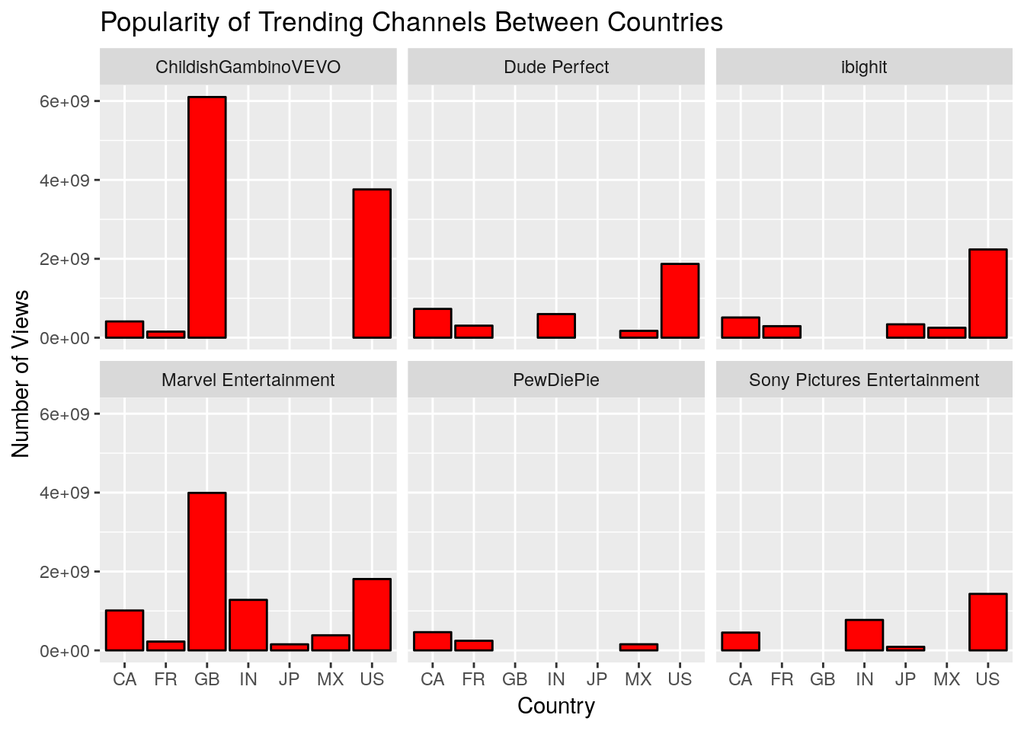

### 9

> Do the same categories trend in each country? (find top 10 trending categories separately for each country)
- Same steps at question 8, but with categories instead of channels.

```
## # A tibble: 10 x 2
##    category_title             views
##    <chr>                      <dbl>
##  1 Entertainment        13671215509
##  2 Music                13179850194
##  3 Comedy                3708438785
##  4 People & Blogs        3228227926
##  5 Sports                2997652188
##  6 Film & Animation      2939060844
##  7 News & Politics       1614610043
##  8 Howto & Style         1570846611
##  9 Science & Technology  1425090421
## 10 Gaming                1241532385
```

```
## # A tibble: 10 x 2
##    category_title            views
##    <chr>                     <dbl>
##  1 Music                5026447522
##  2 Entertainment        3779500229
##  3 Sports               1996811039
##  4 Comedy               1896284649
##  5 People & Blogs       1280843533
##  6 Film & Animation      918517018
##  7 News & Politics       495045563
##  8 Howto & Style         468344413
##  9 Science & Technology  461992294
## 10 Gaming                447160176
```

```
## # A tibble: 10 x 2
##    category_title              views
##    <chr>                       <dbl>
##  1 Music                171160864769
##  2 Entertainment         29786283041
##  3 Film & Animation       8362707626
##  4 People & Blogs         5754287829
##  5 Comedy                 3962062143
##  6 Sports                 3341736194
##  7 Gaming                 1746619532
##  8 Science & Technology   1641388256
##  9 News & Politics        1409131375
## 10 Howto & Style          1190155227
```

```
## # A tibble: 10 x 2
##    category_title             views
##    <chr>                      <dbl>
##  1 Entertainment        16120390974
##  2 Music                10150844485
##  3 Film & Animation      3847149504
##  4 Comedy                2887672070
##  5 News & Politics       1994263812
##  6 Sports                1379949159
##  7 People & Blogs        1364104242
##  8 Howto & Style          737343593
##  9 Science & Technology   477111016
## 10 Gaming                 274722506
```

```
## # A tibble: 10 x 2
##    category_title            views
##    <chr>                     <dbl>
##  1 Entertainment        1766268244
##  2 Music                1070344379
##  3 People & Blogs        587487319
##  4 Sports                580726014
##  5 Film & Animation      311590772
##  6 Comedy                280973914
##  7 Science & Technology  191772211
##  8 News & Politics       186286429
##  9 Gaming                173525830
## 10 Howto & Style         108416992
```

```
## # A tibble: 10 x 2
##    category_title            views
##    <chr>                     <dbl>
##  1 Music                4159713283
##  2 Entertainment        4027574336
##  3 Sports               1389337978
##  4 People & Blogs       1229501908
##  5 Comedy                794647488
##  6 News & Politics       491449042
##  7 Howto & Style         465587429
##  8 Film & Animation      461919619
##  9 Gaming                421961773
## 10 Science & Technology  202863454
```

```
## # A tibble: 10 x 2
##    category_title            views
##    <chr>                     <dbl>
##  1 Entertainment        2088743148
##  2 Music                1605269644
##  3 People & Blogs       1564739895
##  4 Comedy               1021361186
##  5 News & Politics       739248272
##  6 Film & Animation      540227680
##  7 Science & Technology  425486169
##  8 Howto & Style         386912627
##  9 Autos & Vehicles      383781815
## 10 Sports                383133314
```

```
## # A tibble: 10 x 2
##    category_title             views
##    <chr>                      <dbl>
##  1 Music                40132892190
##  2 Entertainment        20604388195
##  3 Film & Animation      7284156721
##  4 Comedy                5117426208
##  5 People & Blogs        4917191726
##  6 Sports                4404456673
##  7 Howto & Style         4078545064
##  8 Science & Technology  3487756816
##  9 Gaming                2141218625
## 10 News & Politics       1473765704
```

The same categories trend in almost every country. Music and Entertainment are the top two most popular categories in every single country we have data for. Other categories that trend in the top 10 of all 8 countries, in no particular order, include Comedy, Film & Animation, Howto & Style, News & Politics, People & Blogs, Science & Technology, and Sports. This means that 9 out of the top 10 trending categories for each country also trend in the other countries.

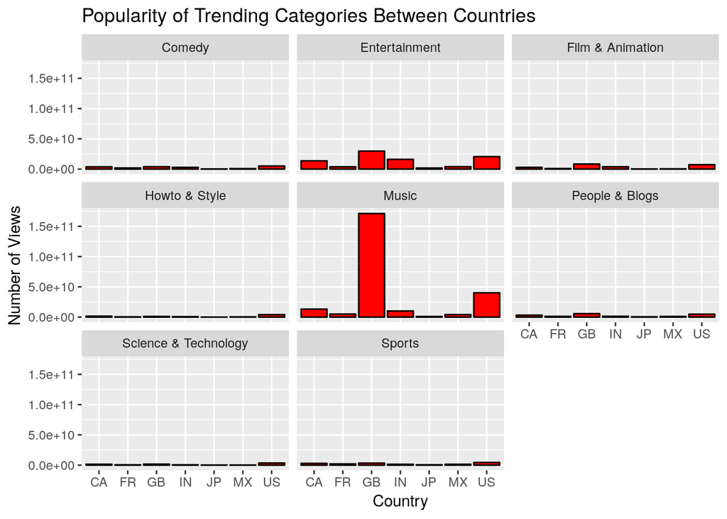

## Generalizations

Similarities across countries:

- categories with the most likes, comments, and views
- music videos tend to be popular
- clickbait tends to get more likes/view (but not necessarily more dislikes/view)
- many categories trend across multiple countries

Differences across Countries:

- frequency of clickbait varies
- still some variation in the most popular channels across countries